# Wine Chemometrics

## Introduction

The following report is a short discovery task in creating a Partial Least Squares Regression model to predict wine quality in the given [dataset](https://archive.ics.uci.edu/ml/datasets/Wine+Quality).

## Exploratory Data Analysis

The first step to any exploration is determining the type of distribution of each variable.

The strengths of PLS Regression is it’s suitability for dealing with multicollinearity. Since our data set deals with chemical properties of the wine, our variables are likely dependent. For a sanity check, we’ll create a correlation matrix.

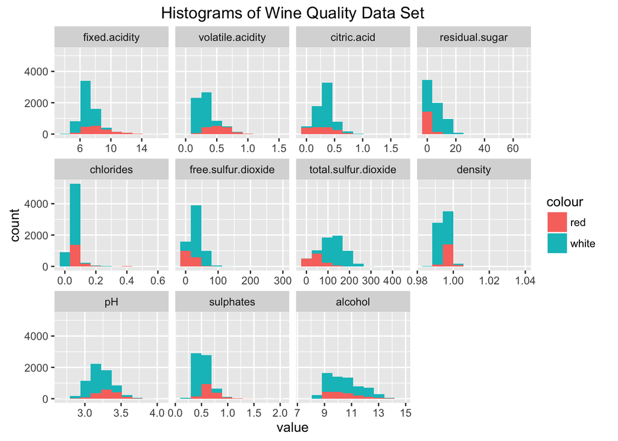

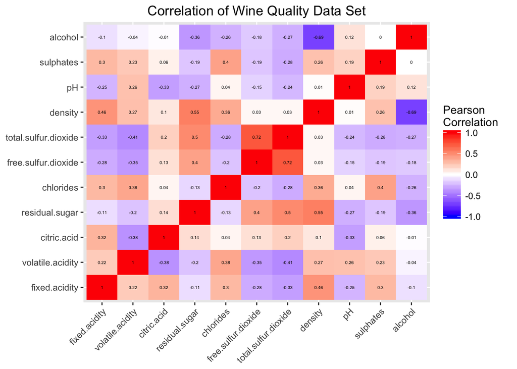

Alcohol and density seem to have the strongest correlation to our target variable, quality. However both variables have high multicollinearity. While they may have posed a problem in ordinary least squares, it’s perfectly handled in PLS.

## Pre-Processing

In the original loading of the variables, we distinguish between red and white through a string.

To communicate this difference to our model, we convert this label via the R factor function. Since the target variable is a scale, we also want to specify an ordering.

When building a model, it’s important to split our data to prevent overfitting. We’ll use the caret package to ensure that our train and test have relatively equal amounts of our factor variable.

This does present a bit of a bias as we are assuming that all new data we feed into the model will contain the same proportion of red and white wines. It’s a bit better to the alternative of having our training data contain all reds and our training set contain all white.

PLS regression (Friedman, Hastie, and Tibshirani 2001) is not scale invariant, thus our design matrix needs to be standardized to have mean 0 and variance 1. Lucky for us, plsRglm does it automatically!

## Model Building

Since this is my first forray into PLS, the best place to start is from the documentation examples.

The type of regression we are doing is a special case of a generalized linear model, known as ordinal regression. We can easily define this in plsRglm with “pls-glm-polr”.

It’s good practice to split your data set into training and test set. Additionally, we might like a cross validation set for hyperparameter tuning. This might be useful when we need to validate the optimal number of components. This exists as a built in function in PLS, which will perform CV automatically.

The benefits of CV is investigating whether the model design’s performance on random subsets of the original data set. In other words, it simulates the design’s robustness to “unseen” data.

Unfortunately, I’ve been attempting to do CV for a few days with very little progress. The massive computational strength is too demanding for my computer that has the technical sophistication of a toaster.

Instead, I revamp my original plan to utilize more of the hard selection methods in plsRglm and smarter feature engineering practices.

For a good head start, we should try to find our error rate with the optimal number of components before any feature engineering.

PLS has a lovely built in command based on the work of (Bastien, Vinzi, and Tenenhaus 2005). From our hard stopping method, we see that we should retain around 5 components.

|  | AIC | BIC | Missclassed | Chi2_Pearson_Y |
| --- | --- | --- | --- | --- |
| **Nb_Comp_0** | 16563 | 16604 | 3661 | 8387 |
| **Nb_Comp_1** | 15107 | 15155 | 3325 | 6640 |
| **Nb_Comp_2** | 14571 | 14625 | 3071 | 6136 |
| **Nb_Comp_3** | 14313 | 14374 | 3035 | 5893 |
| **Nb_Comp_4** | 14209 | 14277 | 2970 | 5831 |
| **Nb_Comp_5** | 14183 | 14257 | 2956 | 5803 |
| **Nb_Comp_6** | 14175 | 14256 | 2969 | 5798 |

```
## [1] "MAE 0.512390"
```

| 4 | 5 | 6 | 7 | 8 |
| --- | --- | --- | --- | --- |
| 3 | 2065 | 3952 | 476 | 1 |

True

| 3 | 4 | 5 | 6 | 7 | 8 | 9 |
| --- | --- | --- | --- | --- | --- | --- |
| 30 | 216 | 2138 | 2836 | 1079 | 193 | 5 |

On average, we expect to be 0.51 units away from the true quality. On closer inspection though. we notice our simple model might be suffering from low variance but high bias. It’s having trouble predicting the lower and higher ratings.

Next, we’ll look at the predictors to give an idea of what kind of feature engineering we should do.

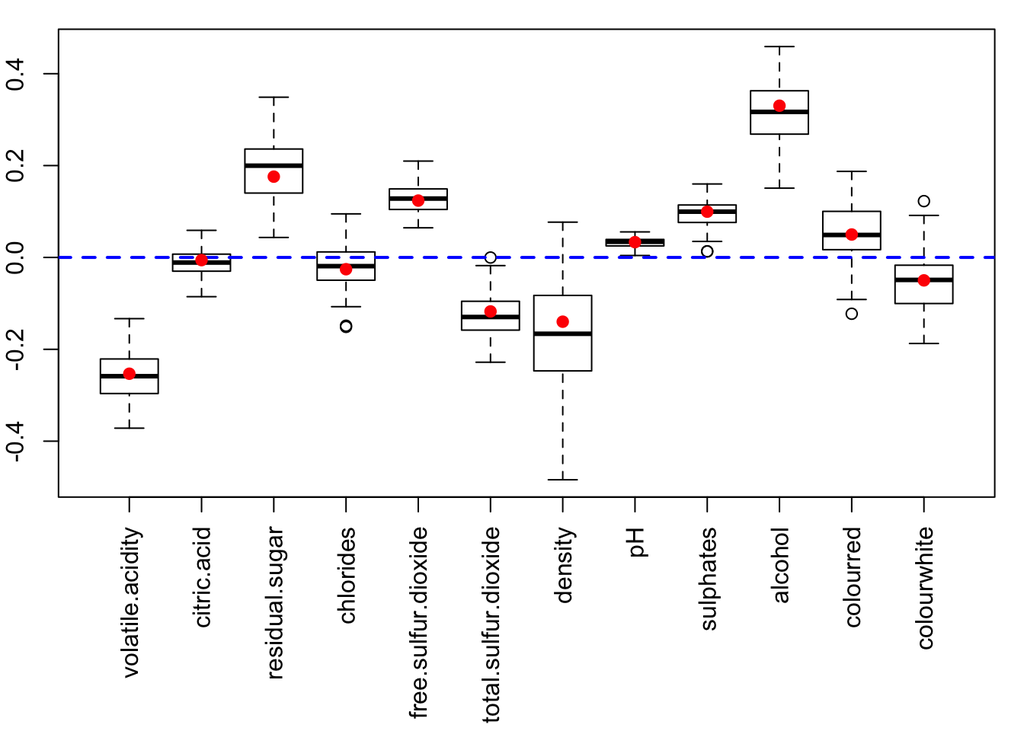

Since citric.acid is quite close to zero, the coefficients are likely not statistically significant. Removing the variable has a mild improvement.

|  | AIC | BIC | Missclassed | Chi2_Pearson_Y |
| --- | --- | --- | --- | --- |
| **Nb_Comp_0** | 16563 | 16604 | 3661 | 8387 |
| **Nb_Comp_1** | 15125 | 15172 | 3296 | 6662 |
| **Nb_Comp_2** | 14551 | 14605 | 3049 | 6105 |
| **Nb_Comp_3** | 14284 | 14345 | 3002 | 5866 |
| **Nb_Comp_4** | 14206 | 14273 | 2970 | 5832 |
| **Nb_Comp_5** | 14191 | 14266 | 2965 | 5822 |
| **Nb_Comp_6** | 14183 | 14264 | 2958 | 5806 |

```
## [1] "MAE 0.510389"
```

| 4 | 5 | 6 | 7 | 8 |
| --- | --- | --- | --- | --- |
| 3 | 2058 | 3953 | 482 | 1 |

True

| 3 | 4 | 5 | 6 | 7 | 8 | 9 |
| --- | --- | --- | --- | --- | --- | --- |
| 30 | 216 | 2138 | 2836 | 1079 | 193 | 5 |

We continue with this manner to see if there are other less significant variables.

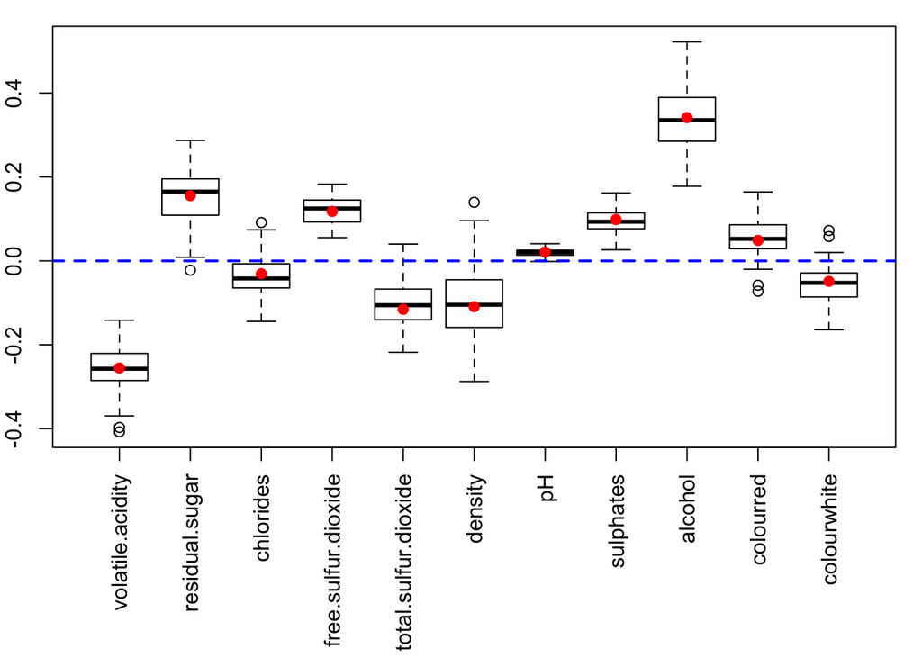

|  | AIC | BIC | Missclassed | Chi2_Pearson_Y |
| --- | --- | --- | --- | --- |
| **Nb_Comp_0** | 16563 | 16604 | 3661 | 8387 |
| **Nb_Comp_1** | 15125 | 15172 | 3296 | 6662 |
| **Nb_Comp_2** | 14546 | 14601 | 3056 | 6105 |
| **Nb_Comp_3** | 14291 | 14352 | 3009 | 5886 |
| **Nb_Comp_4** | 14213 | 14281 | 2981 | 5845 |
| **Nb_Comp_5** | 14201 | 14275 | 2964 | 5838 |
| **Nb_Comp_6** | 14195 | 14277 | 2955 | 5830 |

```
## [1] "MAE 0.508388"
```

| 4 | 5 | 6 | 7 | 8 |
| --- | --- | --- | --- | --- |
| 3 | 2053 | 3966 | 474 | 1 |

| 3 | 4 | 5 | 6 | 7 | 8 | 9 |
| --- | --- | --- | --- | --- | --- | --- |
| 30 | 216 | 2138 | 2836 | 1079 | 193 | 5 |

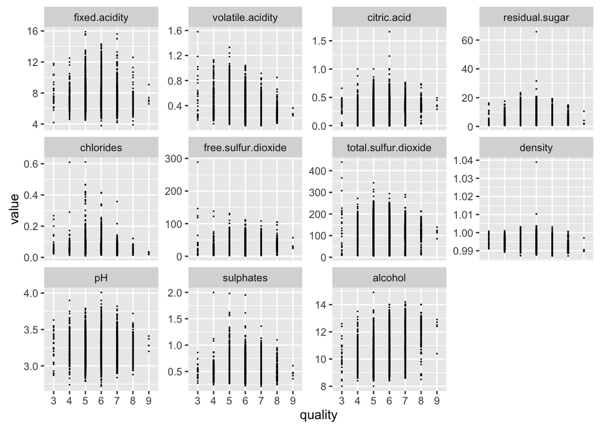

There’s a slight linear trend within alcohol. We try to create a dummy variable such that any values above the mean will be flagged with 1 and everything else with zero.

It might help with flagging more sensitive values.

|  | AIC | BIC | Missclassed | Chi2_Pearson_Y |
| --- | --- | --- | --- | --- |
| **Nb_Comp_0** | 16563 | 16604 | 3661 | 8387 |
| **Nb_Comp_1** | 14953 | 15001 | 3222 | 6626 |
| **Nb_Comp_2** | 14575 | 14629 | 3056 | 6256 |
| **Nb_Comp_3** | 14357 | 14418 | 2994 | 6010 |
| **Nb_Comp_4** | 14227 | 14294 | 2995 | 5854 |
| **Nb_Comp_5** | 14207 | 14282 | 2985 | 5842 |
| **Nb_Comp_6** | 14201 | 14283 | 2980 | 5836 |
| **Nb_Comp_7** | 14196 | 14284 | 2982 | 5841 |

```
## [1] "MAE 0.511313"
```

| 4 | 5 | 6 | 7 | 8 |
| --- | --- | --- | --- | --- |
| 3 | 2033 | 3983 | 477 | 1 |

True

| 3 | 4 | 5 | 6 | 7 | 8 | 9 |
| --- | --- | --- | --- | --- | --- | --- |
| 30 | 216 | 2138 | 2836 | 1079 | 193 | 5 |

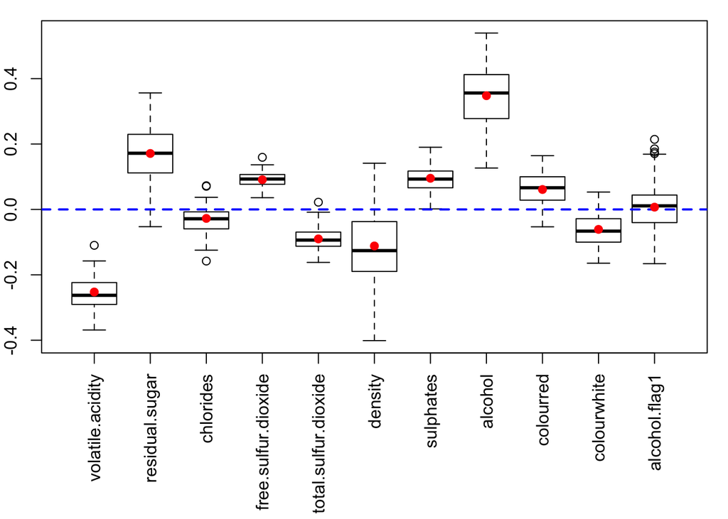

Unfortunately, that attempt did not yield anything fruitful.

My next attempt will to be force highly correlated features into the model only. Using PLS natural talent, this design of the model will only run on a subset of features selected with Caret findCorrelation.

|  | AIC | BIC | Missclassed | Chi2_Pearson_Y |
| --- | --- | --- | --- | --- |
| **Nb_Comp_0** | 16563 | 16604 | 3661 | 8387 |
| **Nb_Comp_1** | 15991 | 16038 | 3517 | 7551 |
| **Nb_Comp_2** | 15851 | 15905 | 3545 | 7410 |
| **Nb_Comp_3** | 15484 | 15545 | 3454 | 7107 |
| **Nb_Comp_4** | 15445 | 15513 | 3479 | 7117 |

```
## [1] "MAE 0.616284"
```

| 3 | 5 | 6 | 7 |
| --- | --- | --- | --- |
| 1 | 1758 | 4553 | 185 |

True

| 3 | 4 | 5 | 6 | 7 | 8 | 9 |
| --- | --- | --- | --- | --- | --- | --- |
| 30 | 216 | 2138 | 2836 | 1079 | 193 | 5 |

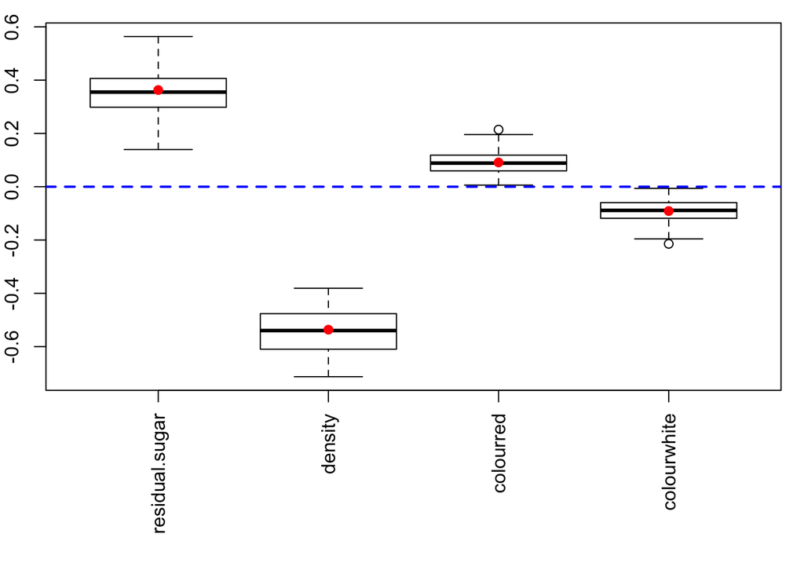

Very much like above, there was no noticeable improvement in MAE.

My very last desperate attempt inspired by a very helpful tip is to cluster the predictors via KMeans, their membership will then be encoded by a dummy variable.

We naturally pick as many groups as there are unique ratings. Since we want the clustering algorithim to find natural grouping, that the PLS may not detect.

|  | AIC | BIC | Missclassed | Chi2_Pearson_Y |
| --- | --- | --- | --- | --- |
| **Nb_Comp_0** | 16563 | 16604 | 3661 | 8387 |
| **Nb_Comp_1** | 15077 | 15124 | 3319 | 6598 |
| **Nb_Comp_2** | 14578 | 14632 | 3151 | 6156 |
| **Nb_Comp_3** | 14342 | 14403 | 3072 | 6021 |
| **Nb_Comp_4** | 14203 | 14270 | 2990 | 5869 |
| **Nb_Comp_5** | 14151 | 14225 | 2959 | 5786 |
| **Nb_Comp_6** | 14142 | 14223 | 2955 | 5773 |

```
## [1] "MAE 0.507773"
```

| 4 | 5 | 6 | 7 | 8 |
| --- | --- | --- | --- | --- |
| 3 | 2066 | 3920 | 507 | 1 |

True

| 3 | 4 | 5 | 6 | 7 | 8 | 9 |
| --- | --- | --- | --- | --- | --- | --- |
| 30 | 216 | 2138 | 2836 | 1079 | 193 | 5 |

At last, some movement within the MAE.

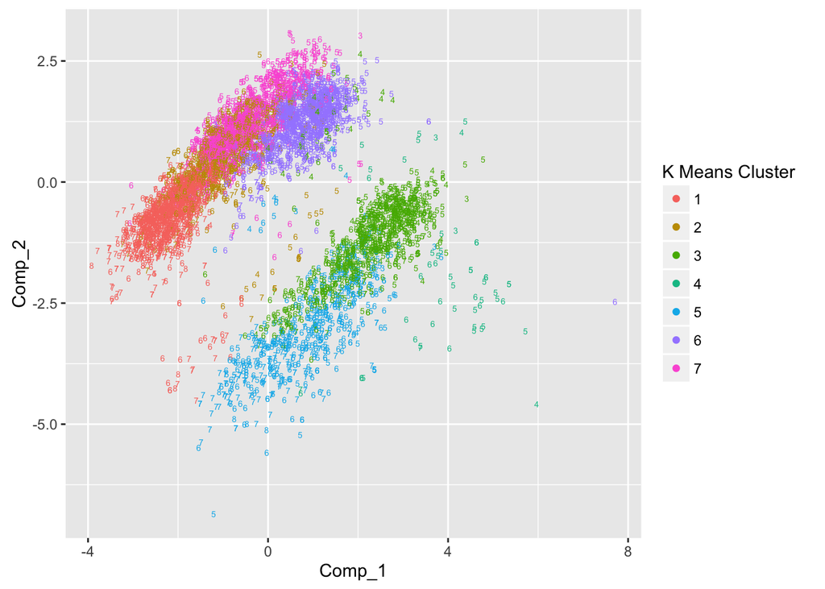

For fun, here is a very nice ggplot.

# Conclusion

PLS regression gained notoriety in it’s use of chemometric applications. (Abdi 2010) It’s impartiality towards multicollinearity makes it ideal for high dimensional data. (More features than observations)

As this was my first introduction to the technique, I’m extremely impressed with it’s simplicity. Mostly what I found challenging about this task was navigating the vast world of R. The price for having a deeply flexible and powerful statistical tool is the endless customization possibilities.

Overall, what I would have liked to extend the project is building separate models for each type of wine, possibly incorporating geographical location, and reviewer specific characteristics.

I hope to discuss more in person!

# References

Abdi, Hervé. 2010. “Partial Least Squares Regression and Projection on Latent Structure Regression (Pls Regression).” *Wiley Interdisciplinary Reviews: Computational Statistics* 2 (1). Wiley Online Library: 97–106.

Bastien, Philippe, Vincenzo Esposito Vinzi, and Michel Tenenhaus. 2005. “PLS Generalised Linear Regression.” *Computational Statistics & Data Analysis* 48 (1). Elsevier: 17–46.

Friedman, Jerome, Trevor Hastie, and Robert Tibshirani. 2001. *The Elements of Statistical Learning*. Vol. 1. Springer series in statistics Springer, Berlin.